```python
from IPython.core.display import display, HTML
display(HTML("<style>.container { width:100% !important; }</style>"))
```

# Cis Modeling Tutorial

In this tutorial I will cover how to use the new RP model API to predict gene expression and find trans-regulated genes. The `CisModeler` is the entry for all methods, and implements an sklearn-style API similar to the topic models, namely `fit`, `score`, `predict`, and `get_logp`.

```python
#kladi imports
from kladi.rp_model import CisModeler
from kladi.matrix_models.estimator import ExpressionTrainer, AccessibilityTrainer
from kladi.core.plot_utils import RAW_UMAP, IMPUTED_UMAP #scanpy umap plot formatting shortcuts
#general imports
import anndata
import scanpy as sc
import pandas as pd
import numpy as np
from sklearn.model_selection import train_test_split
import seaborn as sns
```

To instantiate a `CisModeler` object, we need to provide trained `AccessibilityModel` and `ExpressionModel` objects.

```python
rna_model = ExpressionTrainer.load('data/mouse_prostate/dispersion_test.pth')
atac_model = AccessibilityTrainer.load('/Users/alynch/Dropbox (Partners HealthCare)/Data/mouse_prostate/best_atac_model.pth')
```

And we also need to load training data. To train cis-models, we must provide expression counts and accessiblity counts with shared barcodes.

```python
joint_rna_data = anndata.read_h5ad('data/mouse_prostate/checkpoint/joint_rna_data.h5ad')
joint_atac_data = anndata.read_h5ad('data/mouse_prostate/checkpoint/joint_atac_data.h5ad')
```

```python
assert(all(joint_rna_data.obs_names == joint_atac_data.obs_names)) #make sure barcodes are aligned
```

Lastly, when we instantiate a `CisModeler`, by default it will attempt to learn a model for every gene modeled by the expression topic model. This can be time-consuming, and not every gene may be appropriate or needed for downstream analysis.

I recommend only training RP models for highly variable genes, at least to start. For this tutorial, I will demonstrate with a sample set of 40 genes.

```python
with open('data/mouse_prostate/test_genes.txt', 'r') as f:
    test_genes = [x.strip() for x in f.readlines()]
```

## General Training Procedure

```python
cis_model = CisModeler('mm10', #species
                       expression_model=rna_model,
                       accessibility_model=atac_model,
                       genes = test_genes) #to train for all variable genes: rna_model.genes[rna_model.highly_variable]
```

```
No adjacent peaks to gene BRINP3
Gene 1700021F05RIK not in RefSeq database for this species
```

When fitting/predicting/scoring RP models, the expression and accessibility states of the cells must be processed into features. Each modeling method (`fit`, `score`, `predict`, and `get_logp`) takes as arguments:

- accessibility_matrix
- expression
- (optionally, to save time computing it) accessiblity_latent_compositions

Processing these features is time-consuming, often taking longer than the actual modeling step itself. To mitigate this, when you supply these features to the `cis_model` object, it will process and save the features.

Then, for each method call, if they are not provided, the saved features will be used. To get this step out of the way, you can use `CisModeler.load_features`:

```python
cis_model.load_features(expression = joint_rna_data[:, rna_model.genes].X, accessibility_matrix = joint_atac_data.X)
```

Now, if you want to subset the cells into train/test sets, you can simply pass the indices of the sets to the modeling methods, and it will subset the registered features.

In my case, I only have 1000 cells so subsetting significantly reduces my training size and the remaining test set may not be a good representation of the data, so I skip this step.

```
train_idx, test_idx = train_test_split(np.arange(len(joint_rna_data)), train_size=0.8)

cis_model.fit(idx=train_idx)
```

Next, fit the models. Each gene's model is fit using a 2nd-order LBGFS optimizer, whose learning rate is robust and does not need to be tuned as SGD might.

```python
cis_model.fit()
```

```
<kladi.rp_model.CisModeler at 0x7ff1b81fc6d0>
```

Saving and loading is simple, just provide a prefix and each model will be saved as `<prefix>_<gene>.pth`. To reload models. Instantiate a `CisModeler` object as above, then provide the prefix:

```
cis_model.load('data/mouse_prostate/cis_models/')
```

```python
cis_model.save('data/mouse_prostate/cis_models/')
```

Let's evaluate the models:

```python
cis_model.score()
```

```
0.28241319079443633
```

To make predictions on all cells:

```python
cis_predictions = anndata.AnnData(
        X = cis_model.predict(), #predict expression using cis models
        var = pd.DataFrame(index = cis_model.genes), #provide genes as columns
        obs = joint_atac_data.obs, #copy obs from atac data
        obsm = joint_atac_data.obsm) #copy obsm from atac data
```

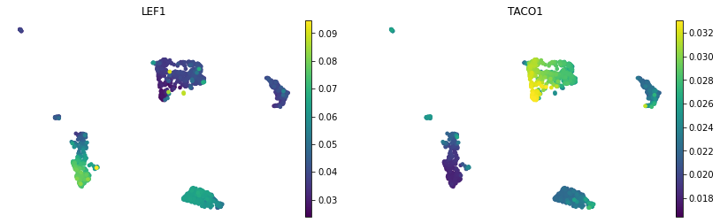

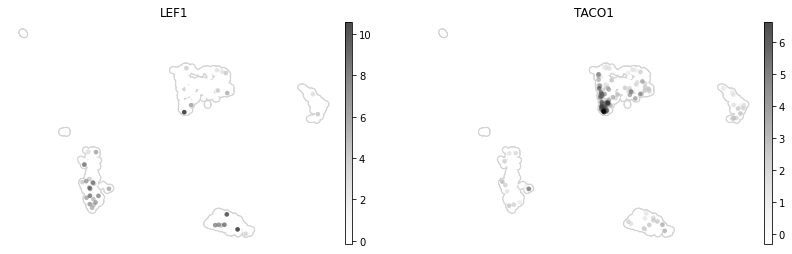

```python
sc.pl.umap(cis_predictions, color = ['LEF1','TACO1'], frameon = False, palette = 'inferno')
sc.pl.umap(joint_rna_data, color = ['LEF1','TACO1'], **RAW_UMAP)
```

To analyze a particular genes' model, you may use the `CisModeler.get_model` method.

Using the `.guide()` method returns the MAP estimates of the model's paramters. Most notably, the `a` paramter scales the effects of upstream/promoter/downstream accessibility, and the `logdistance` parameter shows the upstream and downstream decay distances in Kb, respectively.

```python
cis_model.get_model('TACO1').guide()
```

```
{'cis_TACO1/a': tensor([1.0196e-02, 1.1395e+00, 2.5541e-06], grad_fn=<ExpandBackward>),
 'cis_TACO1/logdistance': tensor([121.1636,   2.2378], grad_fn=<ExpandBackward>),
 'cis_TACO1/theta': tensor(0.1422, grad_fn=<ExpandBackward>),
 'cis_TACO1/gamma': tensor(2.0226, grad_fn=<ExpandBackward>),
 'cis_TACO1/bias': tensor(0.2882, grad_fn=<ExpandBackward>)}
```

## Cis/Trans test

Next, we want to identify genes that show interesting behavior with respect to their proximal chromatin, and to categorize genes based on that relationship. To fascilitate this, we must train a second group of models, this time providing those models with access to the atac latent features, giving them a "view" of the entire cell state from which to make predictions. The performance of these "trans" models relative to the "cis" models serves as the cis/trans test.

Trans models are instantiated in the exact same way as cis models, except to differences noted below:

```python
trans_model = CisModeler(
    'mm10', expression_model=rna_model, accessibility_model=atac_model, genes =test_genes, #same as cis models
    use_trans_features=True, #set to true
    cis_models = cis_model, #provide pre-trained cis models as starting initialization
)
```

```
No adjacent peaks to gene BRINP3
Gene 1700021F05RIK not in RefSeq database for this species
```

```python
trans_model.fit(expression = joint_rna_data[:, rna_model.genes].X, accessibility_matrix = joint_atac_data.X) #example of providing features with method
```

```
<kladi.rp_model.CisModeler at 0x7ff1babb73d0>
```

```python
trans_model.save('data/mouse_prostate/trans_models/')
```

The trans models have the exact same interface and perform all of the same methods as cis models. To identify *trans*-regulated genes, use `CisModeler.cis_trans_test`. It might be a good idea to explicity provide features to this method so that one may be sure the cis and trans models are being scored on the same cells.

(Note: you must call this method from the trans model)

```python
results = trans_model.cis_trans_test(cis_model, #required, provide the cis model to compare predictions
                           expression = joint_rna_data[:, rna_model.genes].X, #features
                           accessibility_matrix = joint_atac_data.X, #features
                           #idx = test_idx --> provide test_idx if applicable
                                    )
```

```python
results = pd.DataFrame(results)
```

```python
print(*results[results.significant].gene.values, sep = ', ')
```

```
TACO1, PLAT, CAPNS1, VCAM1, RORB, LY6A, FAM107B, COL17A1, TNFAIP8, SEL1L, IL1R2, PREX2, ABTB2
```

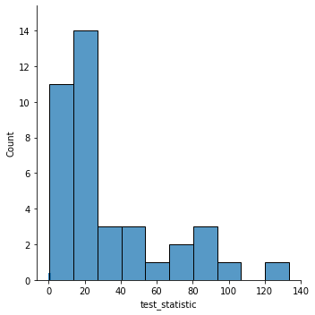

```python
ax = sns.displot(data = results, x = 'test_statistic', bins = 10)
```

It can be useful to compare the probability of observing the data given both models to compare where the *trans* model performed better. We can compare the log-prob of the data given the cis and trans models like so:

```python
delta_logp = anndata.AnnData(X = trans_model.get_logp() - cis_model.get_logp(), # the difference in prob of the trans prediction vs cis prediction. When X > 0, the trans model is doing better.
        var = pd.DataFrame(index = cis_model.genes), #provide genes as columns
        obs = joint_atac_data.obs, #copy obs from atac data
        obsm = joint_atac_data.obsm)

delta_logp.X = np.where(delta_logp.X < 0, np.nan, delta_logp.X) #mask < 0 to make plot more readable
```

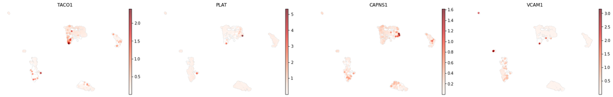

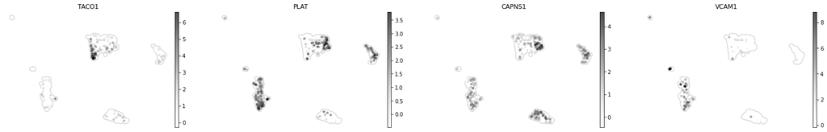

```python
sc.pl.umap(delta_logp, color = results.head(4).gene.values, color_map = 'Reds', na_color='white', add_outline=True, frameon=False, outline_color=('white','lightgrey'))
sc.pl.umap(joint_rna_data, color = results.head(4).gene.values, **RAW_UMAP)
```

## Visualization

Coming soon! I'll work on the install requirements for the Dynamic tracks package.

# Other stuff: Motifs

Here's a rundown on the steps for finding motif hits. I removed the downloading step for motifs and saved them with the package, and I also ran the motifs through a parser so they should be formatted correctly.

```python
import logging
logging.basicConfig(level=logging.INFO)
logging.info('test') # turn on logging to see progress
```

```
INFO:root:test
```

```python
atac_model.get_motif_hits_in_peaks('/Users/alynch/genomes/mm10/mm10.fa')
```

[output not shown]

Save hits data

```python
atac_model.save_hits_data('data/mouse_prostate/atac_model_data.pth')
# to load: atac_model.load_hits_data('data/mouse_prostate/atac_model_data.pth')
```

Filter factors in the hits data for those found in the expression data

```python
atac_model.filter_factors(joint_rna_data.var_names)
```

List TFs by enrichment in topic:

```python
atac_model.enrich_TFs(8)[:20]
```

```
[('MA1104.2', 'GATA6', 3.5518861905786013e-144, 1.6467506658877005),
 ('MA0482.2', 'GATA4', 1.2606122867973607e-143, 1.6522788970078472),
 ('MA0036.3', 'GATA2', 4.595947933961744e-140, 1.6733525252400563),
 ('MA0037.3', 'GATA3', 9.894863993686855e-136, 1.6706712214179162),
 ('MA0851.1', 'FOXJ3', 2.957152669167175e-129, 1.462610474242792),
 ('MA0032.2', 'FOXC1', 1.5780332790124106e-116, 1.4577195639332938),
 ('MA0148.4', 'FOXA1', 8.758780748174128e-104, 1.480175093672573),
 ('MA0481.3', 'FOXP1', 4.0919008371602687e-103, 1.463839172902741),
 ('MA1606.1', 'FOXF1', 2.221070408134676e-100, 1.4397008130740787),
 ('MA1103.2', 'FOXK2', 1.9053891898580628e-93, 1.4724966644701105),
 ('MA0848.1', 'FOXO4', 1.9085179842322036e-91, 1.4661303817303075),
 ('MA0593.1', 'FOXP2', 1.84289197176993e-87, 1.3934729887289605),
 ('MA0852.2', 'FOXK1', 8.408089792885883e-83, 1.434627165311404),
 ('MA0614.1', 'FOXJ2', 2.023650415481049e-82, 1.4621263094375214),
 ('MA0157.2', 'FOXO3', 5.3473680775209625e-81, 1.489623305329279),
 ('MA1279.1', 'COG1', 4.317412731989247e-43, 1.2095407146898005),
 ('MA0040.1', 'FOXQ1', 4.543233628267037e-41, 1.2973901655150888),
 ('MA0480.1', 'FOXO1', 1.654603318170009e-40, 1.2534923743050739),
 ('MA1105.2', 'GRHL2', 1.0642802206687087e-35, 1.2787231325757487),
 ('MA1489.1', 'FOXN3', 6.40647894804195e-34, 1.491252398572033)]
```

Compare topic TF enrichments:

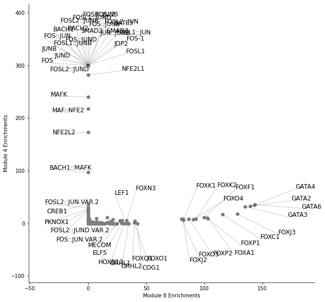

```python
atac_model.plot_compare_module_enrichments(8,4, label_closeness=1.5, figsize=(10,10), pval_threshold=(1e-25,1e-25))
```